# Risk Factor Analysis

## Outcome Variable

**Outcome Variable:** pers_wasted624

## Predictor Variables

**Intervention Variable:** ever_wasted06_noBW

**Adjustment Set:**

unadjusted

## Stratifying Variables

The analysis was stratified on these variable(s):

- studyid
- country

## Data Summary

| studyid | country | ever_wasted06_noBW | pers_wasted624 | n_cell | n |
| --- | --- | --- | --- | --- | --- |
| ki0047075b-MAL-ED | BANGLADESH | 0 | 0 | 210 | 239 |
| ki0047075b-MAL-ED | BANGLADESH | 0 | 1 | 11 | 239 |
| ki0047075b-MAL-ED | BANGLADESH | 1 | 0 | 11 | 239 |
| ki0047075b-MAL-ED | BANGLADESH | 1 | 1 | 7 | 239 |
| ki0047075b-MAL-ED | BRAZIL | 0 | 0 | 193 | 201 |
| ki0047075b-MAL-ED | BRAZIL | 0 | 1 | 1 | 201 |
| ki0047075b-MAL-ED | BRAZIL | 1 | 0 | 7 | 201 |
| ki0047075b-MAL-ED | BRAZIL | 1 | 1 | 0 | 201 |
| ki0047075b-MAL-ED | INDIA | 0 | 0 | 180 | 229 |
| ki0047075b-MAL-ED | INDIA | 0 | 1 | 13 | 229 |
| ki0047075b-MAL-ED | INDIA | 1 | 0 | 26 | 229 |
| ki0047075b-MAL-ED | INDIA | 1 | 1 | 10 | 229 |
| ki0047075b-MAL-ED | NEPAL | 0 | 0 | 217 | 232 |
| ki0047075b-MAL-ED | NEPAL | 0 | 1 | 0 | 232 |
| ki0047075b-MAL-ED | NEPAL | 1 | 0 | 14 | 232 |
| ki0047075b-MAL-ED | NEPAL | 1 | 1 | 1 | 232 |
| ki0047075b-MAL-ED | PERU | 0 | 0 | 257 | 264 |
| ki0047075b-MAL-ED | PERU | 0 | 1 | 2 | 264 |
| ki0047075b-MAL-ED | PERU | 1 | 0 | 5 | 264 |
| ki0047075b-MAL-ED | PERU | 1 | 1 | 0 | 264 |
| ki0047075b-MAL-ED | SOUTH AFRICA | 0 | 0 | 246 | 257 |
| ki0047075b-MAL-ED | SOUTH AFRICA | 0 | 1 | 0 | 257 |
| ki0047075b-MAL-ED | SOUTH AFRICA | 1 | 0 | 10 | 257 |
| ki0047075b-MAL-ED | SOUTH AFRICA | 1 | 1 | 1 | 257 |
| ki0047075b-MAL-ED | TANZANIA, UNITED REPUBLIC OF | 0 | 0 | 236 | 244 |
| ki0047075b-MAL-ED | TANZANIA, UNITED REPUBLIC OF | 0 | 1 | 0 | 244 |
| ki0047075b-MAL-ED | TANZANIA, UNITED REPUBLIC OF | 1 | 0 | 8 | 244 |
| ki0047075b-MAL-ED | TANZANIA, UNITED REPUBLIC OF | 1 | 1 | 0 | 244 |
| ki1000107-Serrinha-VitA | BRAZIL | 0 | 0 | 10 | 11 |
| ki1000107-Serrinha-VitA | BRAZIL | 0 | 1 | 1 | 11 |

[output cut: 126 more lines]

The following strata were considered:

- studyid: ki0047075b-MAL-ED, country: BANGLADESH
- studyid: ki0047075b-MAL-ED, country: BRAZIL
- studyid: ki0047075b-MAL-ED, country: INDIA
- studyid: ki0047075b-MAL-ED, country: NEPAL
- studyid: ki0047075b-MAL-ED, country: PERU
- studyid: ki0047075b-MAL-ED, country: SOUTH AFRICA
- studyid: ki0047075b-MAL-ED, country: TANZANIA, UNITED REPUBLIC OF
- studyid: ki1000107-Serrinha-VitA, country: BRAZIL
- studyid: ki1000108-CMC-V-BCS-2002, country: INDIA
- studyid: ki1000108-IRC, country: INDIA
- studyid: ki1000109-EE, country: PAKISTAN
- studyid: ki1000109-ResPak, country: PAKISTAN
- studyid: ki1000304-VITAMIN-A, country: INDIA
- studyid: ki1000304b-SAS-CompFeed, country: INDIA
- studyid: ki1000304b-SAS-FoodSuppl, country: INDIA
- studyid: ki1017093-NIH-Birth, country: BANGLADESH
- studyid: ki1017093b-PROVIDE, country: BANGLADESH
- studyid: ki1017093c-NIH-Crypto, country: BANGLADESH
- studyid: ki1033518-iLiNS-DYAD-G, country: GHANA
- studyid: ki1066203-TanzaniaChild2, country: TANZANIA, UNITED REPUBLIC OF
- studyid: ki1101329-Keneba, country: GAMBIA
- studyid: ki1112895-Burkina Faso Zn, country: BURKINA FASO
- studyid: ki1112895-Guatemala BSC, country: GUATEMALA
- studyid: ki1113344-GMS-Nepal, country: NEPAL
- studyid: ki1114097-CMIN, country: BANGLADESH
- studyid: ki1114097-CMIN, country: BRAZIL
- studyid: ki1114097-CMIN, country: GUINEA-BISSAU
- studyid: ki1114097-CMIN, country: PERU
- studyid: ki1114097-CONTENT, country: PERU
- studyid: ki1119695-PROBIT, country: BELARUS
- studyid: ki1126311-ZVITAMBO, country: ZIMBABWE
- studyid: ki1135781-COHORTS, country: GUATEMALA
- studyid: ki1135781-COHORTS, country: INDIA
- studyid: ki1135781-COHORTS, country: PHILIPPINES
- studyid: ki1148112-iLiNS-DOSE, country: MALAWI
- studyid: ki1148112-iLiNS-DYAD-M, country: MALAWI
- studyid: ki1148112-LCNI-5, country: MALAWI
- studyid: kiGH5241-JiVitA-3, country: BANGLADESH
- studyid: kiGH5241-JiVitA-4, country: BANGLADESH

### Dropped Strata

Some strata were dropped due to rare outcomes:

- studyid: ki0047075b-MAL-ED, country: BRAZIL
- studyid: ki0047075b-MAL-ED, country: NEPAL
- studyid: ki0047075b-MAL-ED, country: PERU
- studyid: ki0047075b-MAL-ED, country: SOUTH AFRICA
- studyid: ki0047075b-MAL-ED, country: TANZANIA, UNITED REPUBLIC OF
- studyid: ki1000107-Serrinha-VitA, country: BRAZIL
- studyid: ki1000304b-SAS-FoodSuppl, country: INDIA
- studyid: ki1112895-Burkina Faso Zn, country: BURKINA FASO
- studyid: ki1112895-Guatemala BSC, country: GUATEMALA
- studyid: ki1114097-CMIN, country: BRAZIL
- studyid: ki1114097-CMIN, country: PERU
- studyid: ki1114097-CONTENT, country: PERU
- studyid: ki1148112-iLiNS-DOSE, country: MALAWI
- studyid: ki1148112-iLiNS-DYAD-M, country: MALAWI
- studyid: ki1148112-LCNI-5, country: MALAWI

## Methods Detail

We’re interested in the causal parameters $E[Y_a]$ for all values of $a \in \mathcal{A}$. These parameters represent the mean outcome if, possibly contrary to fact, we intervened to set all units to have $A=a$. Under the randomization and positivity assumptions, these are identified by the statistical parameters $\psi_a=E_W[E_{Y|A,W}(Y|A=a,W)]$. In addition, we’re interested in the mean of $Y$, $E[Y]$ under no intervention (the observed mean). We will estimate these parameters by using SuperLearner to fit the relevant likelihood factors – $E_{Y|A,W}(Y|A=a,W)$ and $p(A=a|W)$, and then updating our likelihood fit using a joint TMLE.

For unadjusted analyses ($W=\{\}$), initial likelihoods were estimated using Lrnr_glm to estimate the simple $E(Y|A)$ and Lrnr_mean to estimate $p(A)$. For adjusted analyses, a small library containing Lrnr_glmnet, Lrnr_xgboost, and Lrnr_mean was used.

Having estimated these parameters, we will then use the delta method to estimate relative risks and attributable risks relative to a prespecified baseline level of $A$.

# Results Detail

## Results Plots

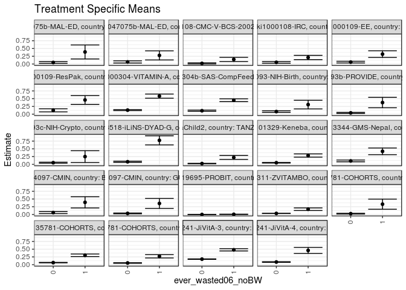

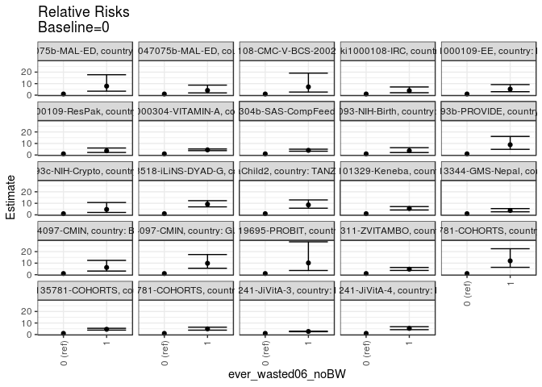

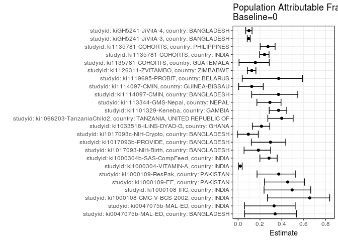

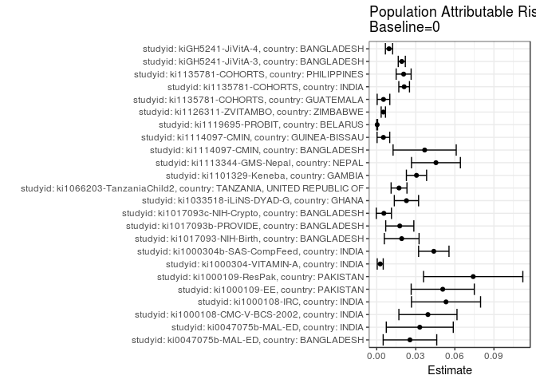

## Results Table

### Parameter: TSM

| studyid | country | intervention_level | baseline_level | estimate | ci_lower | ci_upper |
| --- | --- | --- | --- | --- | --- | --- |
| ki0047075b-MAL-ED | BANGLADESH | 0 | NA | 0.0497738 | 0.0210411 | 0.0785064 |
| ki0047075b-MAL-ED | BANGLADESH | 1 | NA | 0.3888889 | 0.1632078 | 0.6145700 |
| ki0047075b-MAL-ED | INDIA | 0 | NA | 0.0673575 | 0.0319194 | 0.1027956 |
| ki0047075b-MAL-ED | INDIA | 1 | NA | 0.2777778 | 0.1311449 | 0.4244106 |
| ki1000108-CMC-V-BCS-2002 | INDIA | 0 | NA | 0.0206612 | 0.0027136 | 0.0386087 |
| ki1000108-CMC-V-BCS-2002 | INDIA | 1 | NA | 0.1481481 | 0.0810535 | 0.2152428 |
| ki1000108-IRC | INDIA | 0 | NA | 0.0544747 | 0.0266921 | 0.0822573 |
| ki1000108-IRC | INDIA | 1 | NA | 0.2105263 | 0.1411515 | 0.2799011 |
| ki1000109-EE | PAKISTAN | 0 | NA | 0.0610169 | 0.0336653 | 0.0883686 |
| ki1000109-EE | PAKISTAN | 1 | NA | 0.3194444 | 0.2115985 | 0.4272904 |
| ki1000109-ResPak | PAKISTAN | 0 | NA | 0.1250000 | 0.0748743 | 0.1751257 |
| ki1000109-ResPak | PAKISTAN | 1 | NA | 0.4583333 | 0.3170497 | 0.5996170 |
| ki1000304-VITAMIN-A | INDIA | 0 | NA | 0.1312877 | 0.1161493 | 0.1464261 |
| ki1000304-VITAMIN-A | INDIA | 1 | NA | 0.5833333 | 0.5163711 | 0.6502956 |
| ki1000304b-SAS-CompFeed | INDIA | 0 | NA | 0.1111111 | 0.0902541 | 0.1319682 |
| ki1000304b-SAS-CompFeed | INDIA | 1 | NA | 0.4502924 | 0.4050803 | 0.4955045 |
| ki1017093-NIH-Birth | BANGLADESH | 0 | NA | 0.0842572 | 0.0585952 | 0.1099192 |
| ki1017093-NIH-Birth | BANGLADESH | 1 | NA | 0.3095238 | 0.1695697 | 0.4494779 |
| ki1017093b-PROVIDE | BANGLADESH | 0 | NA | 0.0421793 | 0.0256503 | 0.0587082 |
| ki1017093b-PROVIDE | BANGLADESH | 1 | NA | 0.3750000 | 0.2071233 | 0.5428767 |
| ki1017093c-NIH-Crypto | BANGLADESH | 0 | NA | 0.0531609 | 0.0364815 | 0.0698404 |
| ki1017093c-NIH-Crypto | BANGLADESH | 1 | NA | 0.2500000 | 0.0600946 | 0.4399054 |
| ki1033518-iLiNS-DYAD-G | GHANA | 0 | NA | 0.0838852 | 0.0658246 | 0.1019459 |
| ki1033518-iLiNS-DYAD-G | GHANA | 1 | NA | 0.7741935 | 0.6269311 | 0.9214560 |
| ki1066203-TanzaniaChild2 | TANZANIA, UNITED REPUBLIC OF | 0 | NA | 0.0258472 | 0.0183916 | 0.0333028 |
| ki1066203-TanzaniaChild2 | TANZANIA, UNITED REPUBLIC OF | 1 | NA | 0.2228916 | 0.1595636 | 0.2862195 |
| ki1101329-Keneba | GAMBIA | 0 | NA | 0.0520446 | 0.0420099 | 0.0620793 |
| ki1101329-Keneba | GAMBIA | 1 | NA | 0.2852113 | 0.2326868 | 0.3377357 |
| ki1113344-GMS-Nepal | NEPAL | 0 | NA | 0.1108742 | 0.0824326 | 0.1393158 |
| ki1113344-GMS-Nepal | NEPAL | 1 | NA | 0.4197531 | 0.3121799 | 0.5273263 |
| ki1114097-CMIN | BANGLADESH | 0 | NA | 0.0627803 | 0.0308800 | 0.0946806 |
| ki1114097-CMIN | BANGLADESH | 1 | NA | 0.3928571 | 0.2115985 | 0.5741158 |
| ki1114097-CMIN | GUINEA-BISSAU | 0 | NA | 0.0361727 | 0.0235499 | 0.0487955 |
| ki1114097-CMIN | GUINEA-BISSAU | 1 | NA | 0.3571429 | 0.1956767 | 0.5186091 |
| ki1119695-PROBIT | BELARUS | 0 | NA | 0.0006582 | 0.0000015 | 0.0013150 |
| ki1119695-PROBIT | BELARUS | 1 | NA | 0.0067114 | 0.0018519 | 0.0115710 |
| ki1126311-ZVITAMBO | ZIMBABWE | 0 | NA | 0.0356392 | 0.0315969 | 0.0396814 |
| ki1126311-ZVITAMBO | ZIMBABWE | 1 | NA | 0.1714286 | 0.1298063 | 0.2130508 |
| ki1135781-COHORTS | GUATEMALA | 0 | NA | 0.0278100 | 0.0167443 | 0.0388756 |
| ki1135781-COHORTS | GUATEMALA | 1 | NA | 0.3333333 | 0.1702159 | 0.4964508 |
| ki1135781-COHORTS | INDIA | 0 | NA | 0.0662772 | 0.0593563 | 0.0731981 |
| ki1135781-COHORTS | INDIA | 1 | NA | 0.3030928 | 0.2621863 | 0.3439993 |
| ki1135781-COHORTS | PHILIPPINES | 0 | NA | 0.0549717 | 0.0459887 | 0.0639547 |
| ki1135781-COHORTS | PHILIPPINES | 1 | NA | 0.2709924 | 0.2171627 | 0.3248220 |
| kiGH5241-JiVitA-3 | BANGLADESH | 0 | NA | 0.1786589 | 0.1711853 | 0.1861325 |
| kiGH5241-JiVitA-3 | BANGLADESH | 1 | NA | 0.4787946 | 0.4423499 | 0.5152394 |
| kiGH5241-JiVitA-4 | BANGLADESH | 0 | NA | 0.0860080 | 0.0758182 | 0.0961977 |
| kiGH5241-JiVitA-4 | BANGLADESH | 1 | NA | 0.4596774 | 0.3622161 | 0.5571387 |

### Parameter: E(Y)

| studyid | country | intervention_level | baseline_level | estimate | ci_lower | ci_upper |
| --- | --- | --- | --- | --- | --- | --- |
| ki0047075b-MAL-ED | BANGLADESH | NA | NA | 0.0753138 | 0.0417869 | 0.1088408 |
| ki0047075b-MAL-ED | INDIA | NA | NA | 0.1004367 | 0.0614207 | 0.1394527 |
| ki1000108-CMC-V-BCS-2002 | INDIA | NA | NA | 0.0600000 | 0.0350842 | 0.0849158 |
| ki1000108-IRC | INDIA | NA | NA | 0.1076923 | 0.0768872 | 0.1384974 |
| ki1000109-EE | PAKISTAN | NA | NA | 0.1117166 | 0.0794434 | 0.1439898 |
| ki1000109-ResPak | PAKISTAN | NA | NA | 0.1990741 | 0.1456997 | 0.2524484 |
| ki1000304-VITAMIN-A | INDIA | NA | NA | 0.1340000 | 0.1190668 | 0.1489332 |
| ki1000304b-SAS-CompFeed | INDIA | NA | NA | 0.1549509 | 0.1362795 | 0.1736222 |
| ki1017093-NIH-Birth | BANGLADESH | NA | NA | 0.1034483 | 0.0765382 | 0.1303583 |
| ki1017093b-PROVIDE | BANGLADESH | NA | NA | 0.0599002 | 0.0409124 | 0.0788879 |
| ki1017093c-NIH-Crypto | BANGLADESH | NA | NA | 0.0586592 | 0.0414351 | 0.0758833 |
| ki1033518-iLiNS-DYAD-G | GHANA | NA | NA | 0.1067236 | 0.0869433 | 0.1265039 |
| ki1066203-TanzaniaChild2 | TANZANIA, UNITED REPUBLIC OF | NA | NA | 0.0429995 | 0.0338925 | 0.0521065 |
| ki1101329-Keneba | GAMBIA | NA | NA | 0.0826027 | 0.0710097 | 0.0941956 |
| ki1113344-GMS-Nepal | NEPAL | NA | NA | 0.1563636 | 0.1259823 | 0.1867450 |
| ki1114097-CMIN | BANGLADESH | NA | NA | 0.0996016 | 0.0624798 | 0.1367234 |
| ki1114097-CMIN | GUINEA-BISSAU | NA | NA | 0.0413318 | 0.0281047 | 0.0545589 |
| ki1119695-PROBIT | BELARUS | NA | NA | 0.0010471 | 0.0002517 | 0.0018425 |
| ki1126311-ZVITAMBO | ZIMBABWE | NA | NA | 0.0407337 | 0.0365052 | 0.0449622 |
| ki1135781-COHORTS | GUATEMALA | NA | NA | 0.0330296 | 0.0212017 | 0.0448575 |
| ki1135781-COHORTS | INDIA | NA | NA | 0.0873555 | 0.0798578 | 0.0948531 |
| ki1135781-COHORTS | PHILIPPINES | NA | NA | 0.0756579 | 0.0657470 | 0.0855688 |
| kiGH5241-JiVitA-3 | BANGLADESH | NA | NA | 0.1979226 | 0.1904697 | 0.2053756 |
| kiGH5241-JiVitA-4 | BANGLADESH | NA | NA | 0.0954815 | 0.0850302 | 0.1059328 |

### Parameter: RR

| studyid | country | intervention_level | baseline_level | estimate | ci_lower | ci_upper |
| --- | --- | --- | --- | --- | --- | --- |
| ki0047075b-MAL-ED | BANGLADESH | 0 | 0 | 1.000000 | 1.000000 | 1.000000 |
| ki0047075b-MAL-ED | BANGLADESH | 1 | 0 | 7.813131 | 3.446173 | 17.713859 |
| ki0047075b-MAL-ED | INDIA | 0 | 0 | 1.000000 | 1.000000 | 1.000000 |
| ki0047075b-MAL-ED | INDIA | 1 | 0 | 4.123932 | 1.957204 | 8.689340 |
| ki1000108-CMC-V-BCS-2002 | INDIA | 0 | 0 | 1.000000 | 1.000000 | 1.000000 |
| ki1000108-CMC-V-BCS-2002 | INDIA | 1 | 0 | 7.170370 | 2.692106 | 19.098139 |
| ki1000108-IRC | INDIA | 0 | 0 | 1.000000 | 1.000000 | 1.000000 |
| ki1000108-IRC | INDIA | 1 | 0 | 3.864662 | 2.105741 | 7.092804 |
| ki1000109-EE | PAKISTAN | 0 | 0 | 1.000000 | 1.000000 | 1.000000 |
| ki1000109-EE | PAKISTAN | 1 | 0 | 5.235340 | 2.986963 | 9.176137 |
| ki1000109-ResPak | PAKISTAN | 0 | 0 | 1.000000 | 1.000000 | 1.000000 |
| ki1000109-ResPak | PAKISTAN | 1 | 0 | 3.666667 | 2.211100 | 6.080433 |
| ki1000304-VITAMIN-A | INDIA | 0 | 0 | 1.000000 | 1.000000 | 1.000000 |
| ki1000304-VITAMIN-A | INDIA | 1 | 0 | 4.443167 | 3.775988 | 5.228230 |
| ki1000304b-SAS-CompFeed | INDIA | 0 | 0 | 1.000000 | 1.000000 | 1.000000 |
| ki1000304b-SAS-CompFeed | INDIA | 1 | 0 | 4.052632 | 3.264791 | 5.030590 |
| ki1017093-NIH-Birth | BANGLADESH | 0 | 0 | 1.000000 | 1.000000 | 1.000000 |
| ki1017093-NIH-Birth | BANGLADESH | 1 | 0 | 3.673559 | 2.129722 | 6.336524 |
| ki1017093b-PROVIDE | BANGLADESH | 0 | 0 | 1.000000 | 1.000000 | 1.000000 |
| ki1017093b-PROVIDE | BANGLADESH | 1 | 0 | 8.890625 | 4.903944 | 16.118294 |
| ki1017093c-NIH-Crypto | BANGLADESH | 0 | 0 | 1.000000 | 1.000000 | 1.000000 |
| ki1017093c-NIH-Crypto | BANGLADESH | 1 | 0 | 4.702703 | 2.067355 | 10.697444 |
| ki1033518-iLiNS-DYAD-G | GHANA | 0 | 0 | 1.000000 | 1.000000 | 1.000000 |
| ki1033518-iLiNS-DYAD-G | GHANA | 1 | 0 | 9.229202 | 6.924606 | 12.300796 |
| ki1066203-TanzaniaChild2 | TANZANIA, UNITED REPUBLIC OF | 0 | 0 | 1.000000 | 1.000000 | 1.000000 |
| ki1066203-TanzaniaChild2 | TANZANIA, UNITED REPUBLIC OF | 1 | 0 | 8.623427 | 5.752321 | 12.927563 |
| ki1101329-Keneba | GAMBIA | 0 | 0 | 1.000000 | 1.000000 | 1.000000 |
| ki1101329-Keneba | GAMBIA | 1 | 0 | 5.480131 | 4.197550 | 7.154610 |
| ki1113344-GMS-Nepal | NEPAL | 0 | 0 | 1.000000 | 1.000000 | 1.000000 |
| ki1113344-GMS-Nepal | NEPAL | 1 | 0 | 3.785850 | 2.634431 | 5.440515 |
| ki1114097-CMIN | BANGLADESH | 0 | 0 | 1.000000 | 1.000000 | 1.000000 |
| ki1114097-CMIN | BANGLADESH | 1 | 0 | 6.257653 | 3.150183 | 12.430459 |
| ki1114097-CMIN | GUINEA-BISSAU | 0 | 0 | 1.000000 | 1.000000 | 1.000000 |
| ki1114097-CMIN | GUINEA-BISSAU | 1 | 0 | 9.873272 | 5.577368 | 17.478047 |
| ki1119695-PROBIT | BELARUS | 0 | 0 | 1.000000 | 1.000000 | 1.000000 |
| ki1119695-PROBIT | BELARUS | 1 | 0 | 10.195973 | 3.648746 | 28.491398 |
| ki1126311-ZVITAMBO | ZIMBABWE | 0 | 0 | 1.000000 | 1.000000 | 1.000000 |
| ki1126311-ZVITAMBO | ZIMBABWE | 1 | 0 | 4.810119 | 3.679362 | 6.288385 |
| ki1135781-COHORTS | GUATEMALA | 0 | 0 | 1.000000 | 1.000000 | 1.000000 |
| ki1135781-COHORTS | GUATEMALA | 1 | 0 | 11.986111 | 6.379187 | 22.521186 |
| ki1135781-COHORTS | INDIA | 0 | 0 | 1.000000 | 1.000000 | 1.000000 |
| ki1135781-COHORTS | INDIA | 1 | 0 | 4.573108 | 3.855685 | 5.424021 |
| ki1135781-COHORTS | PHILIPPINES | 0 | 0 | 1.000000 | 1.000000 | 1.000000 |
| ki1135781-COHORTS | PHILIPPINES | 1 | 0 | 4.929670 | 3.811624 | 6.375668 |
| kiGH5241-JiVitA-3 | BANGLADESH | 0 | 0 | 1.000000 | 1.000000 | 1.000000 |
| kiGH5241-JiVitA-3 | BANGLADESH | 1 | 0 | 2.679937 | 2.454680 | 2.925865 |
| kiGH5241-JiVitA-4 | BANGLADESH | 0 | 0 | 1.000000 | 1.000000 | 1.000000 |
| kiGH5241-JiVitA-4 | BANGLADESH | 1 | 0 | 5.344591 | 4.206308 | 6.790909 |

### Parameter: PAR

| studyid | country | intervention_level | baseline_level | estimate | ci_lower | ci_upper |
| --- | --- | --- | --- | --- | --- | --- |
| ki0047075b-MAL-ED | BANGLADESH | 0 | NA | 0.0255401 | 0.0049769 | 0.0461032 |
| ki0047075b-MAL-ED | INDIA | 0 | NA | 0.0330792 | 0.0073645 | 0.0587938 |
| ki1000108-CMC-V-BCS-2002 | INDIA | 0 | NA | 0.0393388 | 0.0170347 | 0.0616430 |
| ki1000108-IRC | INDIA | 0 | NA | 0.0532176 | 0.0266933 | 0.0797419 |
| ki1000109-EE | PAKISTAN | 0 | NA | 0.0506997 | 0.0264719 | 0.0749274 |
| ki1000109-ResPak | PAKISTAN | 0 | NA | 0.0740741 | 0.0359566 | 0.1121915 |
| ki1000304-VITAMIN-A | INDIA | 0 | NA | 0.0027123 | 0.0004128 | 0.0050118 |
| ki1000304b-SAS-CompFeed | INDIA | 0 | NA | 0.0438398 | 0.0321712 | 0.0555083 |
| ki1017093-NIH-Birth | BANGLADESH | 0 | NA | 0.0191911 | 0.0058562 | 0.0325259 |
| ki1017093b-PROVIDE | BANGLADESH | 0 | NA | 0.0177209 | 0.0069310 | 0.0285108 |
| ki1017093c-NIH-Crypto | BANGLADESH | 0 | NA | 0.0054983 | -0.0003334 | 0.0113300 |
| ki1033518-iLiNS-DYAD-G | GHANA | 0 | NA | 0.0228384 | 0.0135294 | 0.0321474 |
| ki1066203-TanzaniaChild2 | TANZANIA, UNITED REPUBLIC OF | 0 | NA | 0.0171523 | 0.0110672 | 0.0232373 |
| ki1101329-Keneba | GAMBIA | 0 | NA | 0.0305581 | 0.0228060 | 0.0383102 |
| ki1113344-GMS-Nepal | NEPAL | 0 | NA | 0.0454894 | 0.0267179 | 0.0642609 |
| ki1114097-CMIN | BANGLADESH | 0 | NA | 0.0368213 | 0.0125842 | 0.0610584 |
| ki1114097-CMIN | GUINEA-BISSAU | 0 | NA | 0.0051591 | 0.0003023 | 0.0100159 |
| ki1119695-PROBIT | BELARUS | 0 | NA | 0.0003889 | 0.0000647 | 0.0007130 |
| ki1126311-ZVITAMBO | ZIMBABWE | 0 | NA | 0.0050945 | 0.0034313 | 0.0067577 |
| ki1135781-COHORTS | GUATEMALA | 0 | NA | 0.0052196 | 0.0003645 | 0.0100747 |
| ki1135781-COHORTS | INDIA | 0 | NA | 0.0210783 | 0.0169743 | 0.0251823 |
| ki1135781-COHORTS | PHILIPPINES | 0 | NA | 0.0206862 | 0.0149428 | 0.0264296 |
| kiGH5241-JiVitA-3 | BANGLADESH | 0 | NA | 0.0192637 | 0.0165447 | 0.0219827 |
| kiGH5241-JiVitA-4 | BANGLADESH | 0 | NA | 0.0094735 | 0.0066832 | 0.0122638 |

### Parameter: PAF

| studyid | country | intervention_level | baseline_level | estimate | ci_lower | ci_upper |
| --- | --- | --- | --- | --- | --- | --- |
| ki0047075b-MAL-ED | BANGLADESH | 0 | NA | 0.3391151 | 0.0599964 | 0.5353541 |
| ki0047075b-MAL-ED | INDIA | 0 | NA | 0.3293535 | 0.0588873 | 0.5220904 |
| ki1000108-CMC-V-BCS-2002 | INDIA | 0 | NA | 0.6556474 | 0.2684814 | 0.8379006 |
| ki1000108-IRC | INDIA | 0 | NA | 0.4941634 | 0.2374003 | 0.6644758 |
| ki1000109-EE | PAKISTAN | 0 | NA | 0.4538239 | 0.2413710 | 0.6067797 |
| ki1000109-ResPak | PAKISTAN | 0 | NA | 0.3720930 | 0.1733424 | 0.5230586 |
| ki1000304-VITAMIN-A | INDIA | 0 | NA | 0.0202408 | 0.0027498 | 0.0374251 |
| ki1000304b-SAS-CompFeed | INDIA | 0 | NA | 0.2829268 | 0.1993702 | 0.3577632 |
| ki1017093-NIH-Birth | BANGLADESH | 0 | NA | 0.1855137 | 0.0546616 | 0.2982535 |
| ki1017093b-PROVIDE | BANGLADESH | 0 | NA | 0.2958407 | 0.1207865 | 0.4360410 |
| ki1017093c-NIH-Crypto | BANGLADESH | 0 | NA | 0.0937329 | -0.0075107 | 0.1848026 |
| ki1033518-iLiNS-DYAD-G | GHANA | 0 | NA | 0.2139956 | 0.1302642 | 0.2896660 |
| ki1066203-TanzaniaChild2 | TANZANIA, UNITED REPUBLIC OF | 0 | NA | 0.3988947 | 0.2718960 | 0.5037418 |
| ki1101329-Keneba | GAMBIA | 0 | NA | 0.3699404 | 0.2845143 | 0.4451669 |
| ki1113344-GMS-Nepal | NEPAL | 0 | NA | 0.2909208 | 0.1721595 | 0.3926447 |
| ki1114097-CMIN | BANGLADESH | 0 | NA | 0.3696861 | 0.1245518 | 0.5461803 |
| ki1114097-CMIN | GUINEA-BISSAU | 0 | NA | 0.1248217 | 0.0053667 | 0.2299303 |
| ki1119695-PROBIT | BELARUS | 0 | NA | 0.3713797 | 0.0377469 | 0.5893352 |
| ki1126311-ZVITAMBO | ZIMBABWE | 0 | NA | 0.1250692 | 0.0853196 | 0.1630914 |
| ki1135781-COHORTS | GUATEMALA | 0 | NA | 0.1580293 | 0.0088328 | 0.2847679 |
| ki1135781-COHORTS | INDIA | 0 | NA | 0.2412932 | 0.1971558 | 0.2830041 |
| ki1135781-COHORTS | PHILIPPINES | 0 | NA | 0.2734175 | 0.2020651 | 0.3383894 |
| kiGH5241-JiVitA-3 | BANGLADESH | 0 | NA | 0.0973296 | 0.0836418 | 0.1108129 |
| kiGH5241-JiVitA-4 | BANGLADESH | 0 | NA | 0.0992184 | 0.0699708 | 0.1275463 |